# AA_LINEAR

## Linear Search

Algoritma Linear Search melakukan pencarian pada sebuah array dan mengembalikan index dari nilai yang dicari.

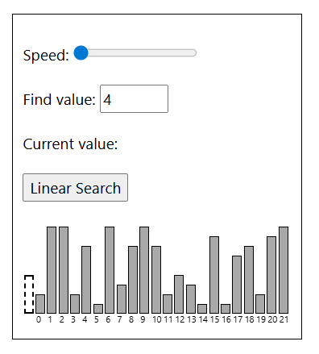

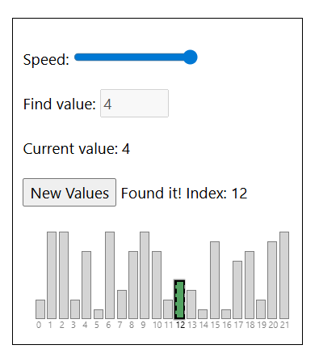

Jalankan simulasi di atas untuk melihat bagaimana algoritma Linear Search bekerja.

Untuk melihat apa yang terjadi ketika sebuah nilai tidak ditemukan, coba cari nilai 5.

Algoritma ini sangat sederhana dan mudah dipahami serta diimplementasikan.

Jika array sudah dalam keadaan terurut, lebih baik menggunakan algoritma Binary Search yang jauh lebih cepat dan akan dipelajari pada halaman berikutnya.

Perbedaan besar antara algoritma sorting dan algoritma searching adalah algoritma sorting memodifikasi array, sedangkan algoritma searching membiarkan array tetap tidak berubah.

Cara Kerja

1. Telusuri array satu per satu mulai dari awal.
2. Bandingkan setiap nilai untuk memeriksa apakah nilainya sama dengan nilai yang dicari.
3. Jika nilai ditemukan, kembalikan index dari nilai tersebut.
4. Jika sudah mencapai akhir array dan nilai tidak ditemukan, kembalikan -1 sebagai tanda bahwa nilai tidak ditemukan.

contoh:

Diberikan sebuah array arr[] yang berisi n bilangan integer, dan sebuah elemen integer x, tentukan apakah elemen x terdapat di dalam array. Kembalikan index dari kemunculan pertama x di dalam array, atau -1 jika elemen tersebut tidak ada.

[output not shown]

Pada Linear Search, kita melakukan iterasi terhadap seluruh elemen array dan memeriksa apakah elemen saat ini sama dengan elemen target. Jika ditemukan elemen yang sama dengan elemen target, maka kembalikan index dari elemen saat ini. Namun jika tidak ada elemen yang sama dengan elemen target, maka kembalikan -1 karena elemen tidak ditemukan.

**Linear Search juga dikenal sebagai Sequential Search.**

Sebagai contoh, perhatikan array berikut:

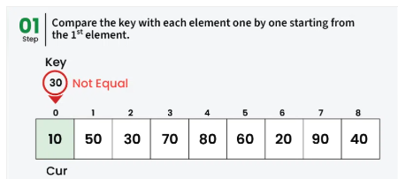

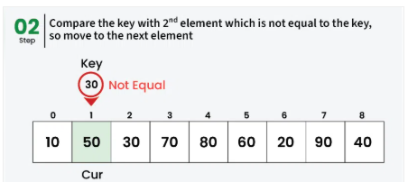

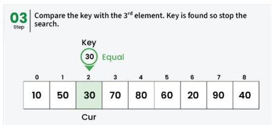

### Manual Run Through

Mari mencoba melakukan proses pencarian secara manual agar lebih memahami bagaimana Linear Search bekerja sebelum mengimplementasikannya menggunakan bahasa pemrograman. Kita akan mencari nilai 11.

Step 1

Kita mulai dengan array yang berisi nilai acak.

```
[12, 8, 9, 11, 5, 11]
```

Step 2

Kita melihat nilai pertama pada array. Apakah nilainya sama dengan 11?

```
[12, 8, 9, 11, 5, 11]
```

Step 3

Kita lanjut ke nilai berikutnya pada index 1, lalu membandingkannya dengan 11 untuk melihat apakah nilainya sama.

```
[12, 8, 9, 11, 5, 11]
```

Step 4

Kita memeriksa nilai berikutnya pada index 2.

```
[12, 8, 9, 11, 5, 11]
```

Step 5

Kita lanjut ke nilai berikutnya pada index 3. Apakah nilainya sama dengan 11?

```
[12, 8, 9, 11, 5, 11]
```

Kita menemukannya!

Nilai 11 ditemukan pada index 3.

Mengembalikan posisi index 3.

Linear Search selesai.

Run the simulation below to see the steps above animated:

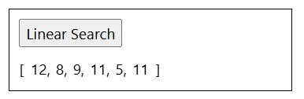

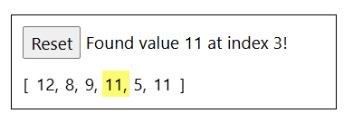

### Manual Run Through: Apa yang Terjadi?

Algoritma ini sebenarnya sangat sederhana.

Setiap nilai diperiksa mulai dari awal array untuk melihat apakah nilainya sama dengan 11, yaitu nilai yang sedang dicari.

Ketika nilai ditemukan, proses pencarian dihentikan, lalu index tempat nilai tersebut ditemukan dikembalikan.

Jika seluruh array sudah diperiksa tetapi nilainya tidak ditemukan, maka -1 akan dikembalikan.

### Linear Search Implementation

Untuk mengimplementasikan algoritma Linear Search, kita membutuhkan:

Sebuah array berisi nilai yang akan dicari. Sebuah nilai target yang ingin dicari. Sebuah loop yang menelusuri array dari awal sampai akhir. Sebuah if-statement yang membandingkan nilai saat ini dengan nilai target, lalu mengembalikan index saat ini jika nilai target ditemukan. Setelah loop selesai, kembalikan -1, karena pada titik tersebut kita tahu bahwa nilai target tidak ditemukan.

Kode hasil implementasi Linear Search terlihat seperti berikut.

Example

```python
def linearSearch(arr, targetVal):
    for i in range(len(arr)):
        if arr[i] == targetVal:
            return i
    return -1

arr = [3, 7, 2, 9, 5]
targetVal = 9

result = linearSearch(arr, targetVal)

if result != -1:
    print("Value",targetVal,"found at index",result)
else:
    print("Value",targetVal,"not found")
```

```
Value 9 found at index 3
```

contoh implementasi lainya

```python
def search(arr, x):
    n = len(arr)

    # Iterate over the array in order to
    # find the key x
    for i in range(0, n):
        if (arr[i] == x):
            return i
    return -1

if __name__ == "__main__":
    arr = [2, 3, 4, 10, 40]
    x = 10

    result = search(arr, x)
    if(result == -1):
        print("Element is not present in array")
    else:
        print(f"Element {x} is present at index, {result}")
```

```
Element 10 is present at index, 3
```

### Linear Search Time Complexity

Jika Linear Search berjalan dan menemukan nilai target sebagai nilai pertama pada array dengan n nilai, maka hanya dibutuhkan satu kali perbandingan.

Namun jika Linear Search harus menelusuri seluruh array yang berisi n nilai tanpa menemukan nilai target, maka dibutuhkan n kali perbandingan.

Hal ini berarti time complexity untuk Linear Search adalah O(n)

### Konsep Linear Search/Sequential Search

Terdapat dua konsep untuk sequential search berdasarkan kumpulan data yang akan dicari, yaitu

#### 1. Unordered List Sequential Search

Pada unordered list sequential search, data berada pada keadaan acak, tidak terurut, sehingga pencarian harus dilakukan mulai dari indeks awal sampai indeks terakhir dari data, atau pencarian berhenti ketika data sudah ditemukan

Berikut implementasi algoritma unordered list sequential search.

```python
def seqSearch(listData, data):
    ind = 0
    found = False
    while ind < len(listData) and not found:
        if listData[ind] == data:
            found = True
        else:
            ind = ind+1
    return found

a=[12,5,9,8,1,10,26]
seqSearch(a,1)
```

```
True
```

#### 2. Ordered List Sequential Search

Pada ordered list sequential search, data sudah dalam keadaan terurut, hal ini tentunya dapat mengurangi waktu komputasi pencarian. Ilustrasi algoritma pencarian ini, dapat dilihat pada Gambar 2 berikut:

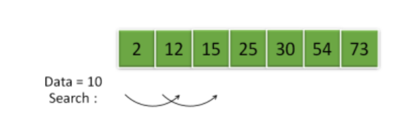

Misalkan data yang dicari adalah 10, pada index kedua dari data tersebut adalah 15, oleh karena itu dapat disimpulkan bahwa data 10 tidak terdapat pada list. karena indeks kedua sampai indeks terakhir memiliki nilai lebih besar dari 15. Sehingga data yang sudah dalam keadaan terurut dapat mempercepat waktu komputasi.

Berikut implementasi algoritma sequential search pada ordered list

```python
def orderedSeqSearch(listData, data):
    ind = 0
    found = False
    stop = False
    position=[]
    while ind < len(listData) and not found and not stop:
        if listData[ind] == data:
            found = True
            position.append(ind)
        else:
            if listData[ind] > data:
                stop = True
            else:
                ind = ind+1
    if found:
        return ind
    else:
        return ('Data tidak ada')

a=[1,1,5,5,5,8,9,10,12,26]
ind=orderedSeqSearch(a,5)
print(ind)
```

```
2
```

### Applications of Linear Search Algorithm

- Unsorted Lists: Ketika kita memiliki array atau list yang belum terurut (unsorted), Linear Search paling umum digunakan untuk mencari suatu elemen di dalam koleksi tersebut.
- Small Data Sets: Linear Search lebih dipilih dibandingkan Binary Search ketika kita memiliki dataset berukuran kecil.
- Searching Linked Lists: Pada implementasi Linked List, Linear Search sering digunakan untuk mencari elemen di dalam list. Setiap node diperiksa secara berurutan sampai elemen yang diinginkan ditemukan.
- Simple Implementation: Linear Search jauh lebih mudah dipahami dan diimplementasikan dibandingkan Binary Search maupun Ternary Search.